# Datos drogadicción IMIM

- Cargamos los datos del estudio a partir de archivos csv y comprobamos que la importación se ha realizado correctamente.

```r
Cannabis <- read.csv('Cannabis.csv')
XTC <- read.csv('XTC.csv')
Controles <- read.csv('Controles.csv')
```

|  | X | vol | sex | age | school | calcaprt | calcapld | corcub | sdmttoco | lnsscore | waisvocd |
| --- | --- | --- | --- | --- | --- | --- | --- | --- | --- | --- | --- |
| 1 | 1 | 13 | 1 | 23 | 17 | 297 | 507 | 19 | 61 | 13 | 53 |
| 2 | 2 | 26 | 2 | 23 | 17 | 280 | 469 | 19 | 65 | 11 | 50 |
| 3 | 3 | 27 | 1 | 23 | 17 | 297 | 527 | 22 | 64 | 13 | 47 |

|  | X | vol | sex | age | school | calcaprt | calcapld | corcub | sdmttoco | lnsscore | waisvocd | id |
| --- | --- | --- | --- | --- | --- | --- | --- | --- | --- | --- | --- | --- |
| 1 | 1 | 1 | 1 | 26 | 15 | 327 | 522 | 23 | 51 | 14 | 48 | 1 |
| 2 | 2 | 2 | 2 | 28 | 16 | 340 | 594 | 17 | 63 | 12 | 59 | 2 |
| 3 | 3 | 3 | 2 | 20 | 14 | 354 | 573 | 16 | 68 | 11 | 41 | 3 |

|  | X | vol | sex | age | school | calcaprt | calcapld | corcub | sdmttoco | lnsscore | waisvocd |
| --- | --- | --- | --- | --- | --- | --- | --- | --- | --- | --- | --- |
| 1 | 1 | 24 | 2 | 22 | 16 | 306 | 532 | 19 | 54 | 16 | 60 |
| 2 | 2 | 25 | 2 | 27 | 20 | 351 | 589 | 16 | 66 | 11 | 47 |
| 3 | 3 | 33 | 2 | 20 | 14 | 391 | 492 | 16 | 61 | 11 | 51 |

- Antes de nada, observemos que el los datos procedentes del grupo de estudio del éxtasis tienen una columna extra llamada ‘id’ que no aporta información. La eliminaremos.

[output not shown]

```r
Cannabis$Group <- 'Cannabis'
XTC$Group <- 'XTC'
Controles$Group <- 'Control'
```

- Ahora fusionaremos los datos en un único data.frame. Lo haremos en dos pasos.

|  | X | vol | sex | age | school | calcaprt | calcapld | corcub | sdmttoco | lnsscore | waisvocd | Group |
| --- | --- | --- | --- | --- | --- | --- | --- | --- | --- | --- | --- | --- |
| 1 | 1 | 1 | 1 | 26 | 15 | 327 | 522 | 23 | 51 | 14 | 48 | XTC |
| 2 | 2 | 2 | 2 | 28 | 16 | 340 | 594 | 17 | 63 | 12 | 59 | XTC |
| 3 | 3 | 3 | 2 | 20 | 14 | 354 | 573 | 16 | 68 | 11 | 41 | XTC |
| 4 | 4 | 4 | 1 | 25 | 10 | 264 | 625 | 20 | 52 | 13 | 32 | XTC |
| 5 | 5 | 5 | 2 | 30 | 16 | 275 | 698 | 17 | 53 | 13 | 45 | XTC |
| 6 | 6 | 6 | 1 | 24 | 18 | 273 | 546 | 20 | 53 | 12 | 54 | XTC |

```r
class(Datos$Group)
```

```
[1] "factor"
```

- Ordenamos el data.frame por el grupo de estudio y el identidicafor de voluntario.

| X | vol | sex | age | school | calcaprt | calcapld | corcub | sdmttoco | lnsscore | waisvocd | Group |
| --- | --- | --- | --- | --- | --- | --- | --- | --- | --- | --- | --- |
| 1 | 13 | 1 | 23 | 17 | 297 | 507 | 19 | 61 | 13 | 53 | Cannabis |
| 2 | 26 | 2 | 23 | 17 | 280 | 469 | 19 | 65 | 11 | 50 | Cannabis |
| 3 | 27 | 1 | 23 | 17 | 297 | 527 | 22 | 64 | 13 | 47 | Cannabis |
| 4 | 30 | 2 | 23 | 17 | 293 | 565 | 23 | 65 | 11 | 46 | Cannabis |
| 5 | 31 | 1 | 21 | 15 | 295 | 481 | 18 | 54 | 11 | 56 | Cannabis |
| 6 | 35 | 2 | 22 | 13 | 243 | 595 | 24 | 74 | 13 | 50 | Cannabis |
| 7 | 45 | 2 | 19 | 13 | 313 | 560 | 16 | 63 | 11 | 47 | Cannabis |
| 8 | 52 | 2 | 24 | 17 | 441 | 536 | 16 | 70 | 9 | 45 | Cannabis |
| 9 | 66 | 2 | 21 | 15 | 367 | 523 | 18 | 72 | 13 | 51 | Cannabis |
| 10 | 70 | 2 | 21 | 15 | 262 | 489 | 22 | 65 | 14 | 56 | Cannabis |

[output cut: 83 more lines]

- ¿Cuántos casos (filas) tiene el data.frame enteros y cuántos si se descartan aquellos con algún dato perdido?

```r
summary(Datos)
```

```
       X               vol              sex             age            school         calcaprt        calcapld         corcub         sdmttoco
 Min.   :  1.00   Min.   :  1.00   Min.   :1.000   Min.   :18.00   Min.   : 7.00   Min.   :239.0   Min.   :455.0   Min.   : 7.00   Min.   :36.00
 1st Qu.:  8.00   1st Qu.: 25.00   1st Qu.:1.000   1st Qu.:21.00   1st Qu.:14.00   1st Qu.:283.0   1st Qu.:523.0   1st Qu.:17.00   1st Qu.:54.00
 Median : 16.00   Median : 60.00   Median :2.000   Median :22.00   Median :15.00   Median :313.0   Median :553.5   Median :18.00   Median :62.00
 Mean   : 24.04   Mean   : 57.58   Mean   :1.624   Mean   :22.76   Mean   :14.83   Mean   :335.6   Mean   :564.5   Mean   :18.25   Mean   :62.12
 3rd Qu.: 26.00   3rd Qu.: 87.00   3rd Qu.:2.000   3rd Qu.:24.00   3rd Qu.:17.00   3rd Qu.:359.0   3rd Qu.:606.0   3rd Qu.:20.00   3rd Qu.:69.00
 Max.   :104.00   Max.   :117.00   Max.   :2.000   Max.   :31.00   Max.   :20.00   Max.   :607.0   Max.   :730.0   Max.   :24.00   Max.   :95.00
                                                                                   NA's   :2       NA's   :3       NA's   :2       NA's   :2
    lnsscore        waisvocd          Group
 Min.   : 8.00   Min.   :30.00   Cannabis:23
 1st Qu.:11.00   1st Qu.:45.00   Control :34
 Median :12.00   Median :48.00   XTC     :36
 Mean   :12.23   Mean   :47.85
 3rd Qu.:13.25   3rd Qu.:51.00
 Max.   :19.00   Max.   :60.00
 NA's   :1
```

```r
length(Datos$vol)
```

```
[1] 93
```

```r
table(datos)
```

```
datos
FALSE  TRUE
    3    90
```

- Convertimos la variable género en un factor cuyos valores son ‘Male’ (sex == 1) o ‘Female’ (sex == 2)

|  | X | vol | sex | age | school | calcaprt | calcapld | corcub | sdmttoco | lnsscore | waisvocd | Group |
| --- | --- | --- | --- | --- | --- | --- | --- | --- | --- | --- | --- | --- |
| 1 | 1 | 1 | Male | 26 | 15 | 327 | 522 | 23 | 51 | 14 | 48 | XTC |
| 2 | 2 | 2 | Female | 28 | 16 | 340 | 594 | 17 | 63 | 12 | 59 | XTC |
| 3 | 3 | 3 | Female | 20 | 14 | 354 | 573 | 16 | 68 | 11 | 41 | XTC |
| 4 | 4 | 4 | Male | 25 | 10 | 264 | 625 | 20 | 52 | 13 | 32 | XTC |
| 5 | 5 | 5 | Female | 30 | 16 | 275 | 698 | 17 | 53 | 13 | 45 | XTC |
| 6 | 6 | 6 | Male | 24 | 18 | 273 | 546 | 20 | 53 | 12 | 54 | XTC |

```r
Datos$age
```

```
 [1] 26 28 20 25 30 24 31 22 21 23 20 21 24 23 30 22 21 19 25 21 22 27 27 31 24 18 20 20 25 29 21 23 23 22 23 24 23 23 23 23 21 22 19 24 21 21 20 20 22 21 21
[52] 21 20 24 26 25 24 21 21 22 27 20 27 26 24 23 23 23 21 20 21 22 21 30 23 23 24 19 19 18 20 21 29 20 21 22 21 22 21 18 21 22 22
```

```r
Datos$intervalos
```

```
 [1] >= 25 >= 25 <= 21 22-24 >= 25 22-24 >= 25 22-24 <= 21 22-24 <= 21 <= 21 22-24 22-24 >= 25 22-24 <= 21 <= 21 22-24 <= 21 22-24 >= 25 >= 25 >= 25 22-24
[26] <NA>  <= 21 <= 21 22-24 >= 25 <= 21 22-24 22-24 22-24 22-24 22-24 22-24 22-24 22-24 22-24 <= 21 22-24 <= 21 22-24 <= 21 <= 21 <= 21 <= 21 22-24 <= 21
[51] <= 21 <= 21 <= 21 22-24 >= 25 22-24 22-24 <= 21 <= 21 22-24 >= 25 <= 21 >= 25 >= 25 22-24 22-24 22-24 22-24 <= 21 <= 21 <= 21 22-24 <= 21 >= 25 22-24
[76] 22-24 22-24 <= 21 <= 21 <NA>  <= 21 <= 21 >= 25 <= 21 <= 21 22-24 <= 21 22-24 <= 21 <NA>  <= 21 22-24 22-24
Levels: <= 21 22-24 >= 25
```

- Crear una variable compuesta (Composite Variable) usando las variables corcub, sdmttoco, lnsscore y waisvocd de la siguiente manera:
  - Estandarizar las cuatro variables (media 0 y desviación estándar 1).
  - Sumar los cuatro valores estandarizados.

```r
Datos$Corcub <- scale(Datos$corcub)
print(round(mean(Datos$Corcub, na.rm = TRUE), 3) == 0)
```

```
[1] TRUE
```

```r
print(round(sd(Datos$Corcub, na.rm = TRUE), 3 ) == 1)
```

```
[1] TRUE
```

```r
Datos$Sdmttoco <- scale(Datos$sdmttoco)
print(round(mean(Datos$Sdmttoco , na.rm = TRUE), 3) == 0)
```

```
[1] TRUE
```

```r
print(round(sd(Datos$Sdmttoco , na.rm = TRUE), 3 ) == 1)
```

```
[1] TRUE
```

```r
Datos$Lnsscore <- scale(Datos$lnsscore)
print(round(mean(Datos$Lnsscore, na.rm = TRUE), 3) == 0)
```

```
[1] TRUE
```

```r
print(round(sd(Datos$Lnsscore, na.rm = TRUE), 3 ) == 1)
```

```
[1] TRUE
```

```r
Datos$Waisvocd <- scale(Datos$waisvocd)
print(round(mean(Datos$Waisvocd , na.rm = TRUE), 3) == 0)
```

```
[1] TRUE
```

```r
print(round(sd(Datos$Waisvocd , na.rm = TRUE), 3 ) == 1)
```

```
[1] TRUE
```

Ahora creo la nueva variable CV (Composite Variable): REVISAR, NO SÉ SI ESTÁ CORRECTO

```r
Datos$CV <- Datos$Corcub + Datos$Sdmttoco + Datos$Lnsscore + Datos$Waisvocd
print(summary(Datos$CV))
```

```
       V1
 Min.   :-8.48611
 1st Qu.:-1.79399
 Median : 0.18393
 Mean   : 0.02944
 3rd Qu.: 1.66967
 Max.   : 6.68849
 NA's   :3
```

```r
print(mean(Datos$CV, na.rm = TRUE))
```

```
[1] 0.02944021
```

```r
print(sd(Datos$CV, na.rm = TRUE))
```

```
[1] 2.749521
```

- Media, mediana, desviación estándar y rango de la variable compuesta de cada grupo.
  - Media grupo <= 21:

```r
print(mean(Datos$CV[which(Datos$intervalos == '<= 21')], na.rm = TRUE))
```

```
[1] 0.3385971
```

```
+ Mediana grupo <= 21:
```

```r
print(median(Datos$CV[which(Datos$intervalos == '<= 21')], na.rm = TRUE))
```

```
[1] 0.1839251
```

```
+ Desviación estándar grupo <= 21:
```

```r
print(sd(Datos$CV[which(Datos$intervalos == '<= 21')], na.rm = TRUE))
```

```
[1] 2.190333
```

```
+ Rango (intercuartil) del grupo <= 21:
```

```r
print(IQR(Datos$CV[which(Datos$intervalos == '<= 21')], na.rm = TRUE))
```

```
[1] 2.540645
```

```
    + Media grupo 22-24:
```

```r
print(mean(Datos$CV[which(Datos$intervalos == '22-24')], na.rm = TRUE))
```

```
[1] -0.04299464
```

```
+ Mediana grupo  22-24:
```

```r
print(median(Datos$CV[which(Datos$intervalos == '22-24')], na.rm = TRUE))
```

```
[1] 0.3226415
```

```
+ Desviación estándar grupo  22-24:
```

```r
print(sd(Datos$CV[which(Datos$intervalos == '22-24')], na.rm = TRUE))
```

```
[1] 3.404455
```

```
+ Rango (intercuartil) del grupo 22-24:
```

```r
print(IQR(Datos$CV[which(Datos$intervalos == '22-24')], na.rm = TRUE))
```

```
[1] 4.432818
```

```
 + Media grupo >= 25:
```

```r
print(mean(Datos$CV[which(Datos$intervalos == '>= 25')], na.rm = TRUE))
```

```
[1] -0.6440967
```

```
+ Mediana grupo >= 25:
```

```r
print(median(Datos$CV[which(Datos$intervalos == '>= 25')], na.rm = TRUE))
```

```
[1] -1.206551
```

```
+ Desviación estándar grupo >= 25:
```

```r
print(sd(Datos$CV[which(Datos$intervalos == '>= 25')], na.rm = TRUE))
```

```
[1] 1.917125
```

```
+ Rango (intercuartil) del grupo >= 25:
```

```r
print(IQR(Datos$CV[which(Datos$intervalos == '>= 25')], na.rm = TRUE))
```

```
[1] 3.113844
```

- Representar la distribución condicionada de la variable edad por el grupo de estudio mediante un gráfico de mosaicos.

```r
tablaCan <- table(Datos$age[which(Datos$Group == 'Cannabis')], dnn = 'Cannabis')
tablaXTC <- table(Datos$age[which(Datos$Group == 'XTC')], dnn = 'XTC')
tablaCon <- table(Datos$age[which(Datos$Group == 'Control')], dnn = 'Control')
print(tablaCan)
```

```
Cannabis
19 20 21 22 23 24 25 26
 1  3  8  2  4  3  1  1
```

```r
print(tablaXTC)
```

```
XTC
18 19 20 21 22 23 24 25 26 27 28 29 30 31
 1  1  4  5  4  5  4  3  1  2  1  1  2  2
```

```r
print(tablaCon)
```

```
Control
18 19 20 21 22 23 24 26 27 29 30
 2  2  4  8  6  5  2  1  2  1  1
```

```
Error: tentativa de aplicar una no-función
```

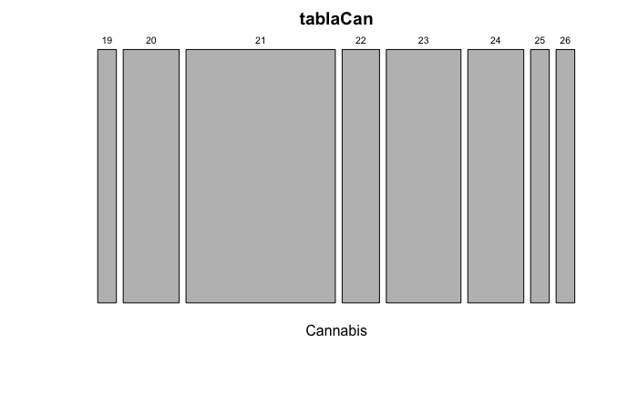

```r
mosaicplot(tablaCan)(tablaCan)
```

```
Error: tentativa de aplicar una no-función
```

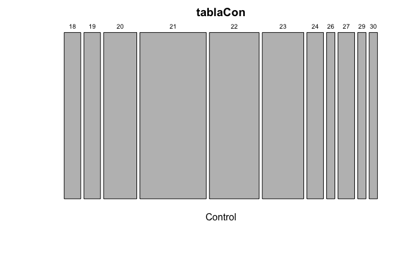

```r
mosaicplot(tablaCon)(tablaCon)
```

```
Error: tentativa de aplicar una no-función
```

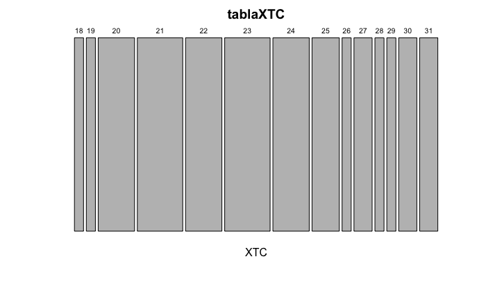

```r
mosaicplot(tablaXTC)(tablaXTC)
```

- Representar la distribución condicionada de la variable edad por grupo de estudio mediante una tabla de contingencia usando la función CrossTable del paquete descr.

```r
#install.packages('descr')
library(descr)
CrossTable(Datos$age, Datos$Group)
```

```
Chi-squared approximation may be incorrect
```

```
   Cell Contents
|-------------------------|
|                       N |
| Chi-square contribution |
|           N / Row Total |
|           N / Col Total |
|         N / Table Total |
|-------------------------|

===============================================
             Datos$Group
Datos$age    Cannabis   Control     XTC   Total
-----------------------------------------------
18                  0         2       1       3
                0.742     0.744   0.022
                0.000     0.667   0.333   0.032
                0.000     0.059   0.028
                0.000     0.022   0.011
-----------------------------------------------
19                  1         2       1       4
                0.000     0.198   0.194
                0.250     0.500   0.250   0.043
                0.043     0.059   0.028
                0.011     0.022   0.011
-----------------------------------------------
20                  3         4       4      11
                0.029     0.000   0.016
                0.273     0.364   0.364   0.118
                0.130     0.118   0.111
                0.032     0.043   0.043
-----------------------------------------------
21                  8         8       5      21
                1.517     0.014   1.204
                0.381     0.381   0.238   0.226
                0.348     0.235   0.139
                0.086     0.086   0.054
-----------------------------------------------
22                  2         6       4      12
                0.316     0.593   0.090
                0.167     0.500   0.333   0.129
```

[output cut: 45 more lines]

```
30                  0         1       2       3
                0.742     0.009   0.606
                0.000     0.333   0.667   0.032
                0.000     0.029   0.056
                0.000     0.011   0.022
-----------------------------------------------
31                  0         0       2       2
                0.495     0.731   1.941
                0.000     0.000   1.000   0.022
                0.000     0.000   0.056
                0.000     0.000   0.022
-----------------------------------------------
Total              23        34      36      93
                0.247     0.366   0.387
===============================================
```

- Exportad vuestro data frame a un fichero EXCEL de tal manera que el fichero EXCEL contenga una hoja por cada grupo de estudio con nombre igual al grupo de estudio. Las tres hojas del fichero ya no deben contener la variable Group. Podéis usar la función write.xlsx del paquete xlsx o la funcióon write.xlsx del paquete openxls.

```r
write.xlsx(Datos[Datos$Group == 'Control',], file =  'Ejercicio1', sheetName = "Control",  col.names = TRUE, row.names = TRUE, append = TRUE, showNA = TRUE)
```

```
Error in createWorkbook(type = ext) : Unknown format Ejercicio1
```

- Ahora haremos gráficos que nos permitan comparar el rendimiento neurocognitivo de los tres grupos de estudio.

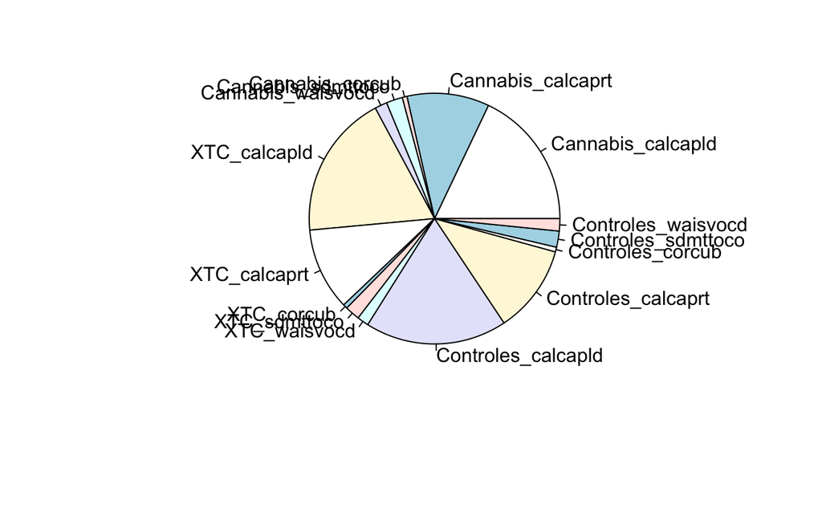

```r
# Creamos los datos
  # Grupo de consumidores de Cannabis
Cannabis_calcapld <- mean(Cannabis$calcapld, na.rm = TRUE)
Cannabis_calcaprt <- mean(Cannabis$calcaprt, na.rm = TRUE)
Cannabis_corcub <- mean(Cannabis$corcub, na.rm = TRUE)
Cannabis_sdmttoco <- mean(Cannabis$sdmttoco, na.rm = TRUE)
Cannabis_waisvocd <- mean(Cannabis$waisvocd, na.rm = TRUE)
  # Grupo de consumidores de Éxtasis
XTC_calcapld <- mean(XTC$calcapld, na.rm = TRUE)
XTC_calcaprt <- mean(XTC$calcaprt, na.rm = TRUE)
XTC_corcub <- mean(XTC$corcub, na.rm = TRUE)
XTC_sdmttoco <- mean(XTC$sdmttoco, na.rm = TRUE)
XTC_waisvocd <- mean(XTC$waisvocd, na.rm = TRUE)
  # Grupo de control
Controles_calcapld <- mean(Controles$calcapld, na.rm = TRUE)
Controles_calcaprt <- mean(Controles$calcaprt, na.rm = TRUE)
Controles_corcub <- mean(Controles$corcub, na.rm = TRUE)
Controles_sdmttoco <- mean(Controles$sdmttoco, na.rm = TRUE)
Controles_waisvocd <- mean(Controles$waisvocd, na.rm = TRUE)
  # Creamos un vector con todos los datos y un vector de etiquetas:
MEDIAS <- c(Cannabis_calcapld, Cannabis_calcaprt, Cannabis_corcub, Cannabis_sdmttoco, Cannabis_waisvocd,
            XTC_calcapld, XTC_calcaprt, XTC_corcub, XTC_sdmttoco, XTC_waisvocd,
            Controles_calcapld, Controles_calcaprt, Controles_corcub, Controles_sdmttoco, Controles_waisvocd)
LABELS <- c('Cannabis_calcapld', 'Cannabis_calcaprt', 'Cannabis_corcub', 'Cannabis_sdmttoco', 'Cannabis_waisvocd',
            'XTC_calcapld', 'XTC_calcaprt', 'XTC_corcub', 'XTC_sdmttoco', 'XTC_waisvocd',
            'Controles_calcapld', 'Controles_calcaprt', 'Controles_corcub', 'Controles_sdmttoco', 'Controles_waisvocd')

pie(MEDIAS , labels = LABELS)
```

```
+ Este gráfico es correcto, pero no nos permite observar nada claramente:
```

```r
# Libraries
library(tidyverse)

# Create dataset
data = data.frame(
  id = seq(1,15),
  medias = c(Cannabis_calcapld, XTC_calcapld, Controles_calcapld,
             Cannabis_calcaprt, XTC_calcaprt, Controles_calcaprt,
             Cannabis_corcub, XTC_corcub, Controles_corcub,
             Cannabis_sdmttoco, XTC_sdmttoco, Controles_sdmttoco,
             Cannabis_waisvocd, XTC_waisvocd, Controles_waisvocd),
  grupo = c('Cannabis', 'XTC', 'Control',
            'Cannabis', 'XTC', 'Control',
            'Cannabis', 'XTC', 'Control',
            'Cannabis', 'XTC', 'Control',
            'Cannabis', 'XTC', 'Control'),
  variables = c ('calcapld', 'calcapld', 'calcapld',
                 'calcaprt', 'calcaprt', 'calcaprt',
                 'corcub', 'corcub', 'corcub',
                 'sdmttoco', 'sdmttoco', 'sdmttoco',
                 'waisvocd', 'waisvocd', 'waisvocd')
)
# ----- This section prepare a dataframe for labels ---- #
# Get the name and the y position of each label
label_data = data
# calculate the ANGLE of the labels
number_of_bar = nrow(label_data)
angle = 90 - 360 * (label_data$id-0.5) /number_of_bar     # I substract 0.5 because the letter must have the angle of the center of the bars. Not extreme right(1) or extreme left (0)

# calculate the alignment of labels: right or left
# If I am on the left part of the plot, my labels have currently an angle < -90
label_data$hjust <- ifelse( angle < -90, 1, 0)

# flip angle BY to make them readable
label_data$angle <- ifelse(angle < -90, angle + 180, angle)
# ----- ------------------------------------------- ---- #


# Start the plot
p = ggplot(data, aes(x = as.factor(id), y = value)) +       # Note that id is a factor. If x is numeric, there is some space between the first bar

  # This add the bars with a blue color
  geom_bar(stat = "identity", fill = alpha("skyblue", 0.7)) +

  # Limits of the plot = very important. The negative value controls the size of the inner circle, the positive one is useful to add size over each bar
  ylim(-100,120) +

  # Custom the theme: no axis title and no cartesian grid
  theme_minimal() + theme( axis.text = element_blank(),
                           axis.title = element_blank(),
                           panel.grid = element_blank(),
                           plot.margin = unit(rep(-1,4), "cm")      # Adjust the margin to make in sort labels are not truncated!
                           ) +

  # This makes the coordinate polar instead of cartesian.
  coord_polar(start = 0) +

  # Add the labels, using the label_data dataframe that we have created before
  geom_text(data = label_data, aes(x = id, y = medias + 10, label = individual, hjust = hjust), color = "black", fontface = "bold", alpha = 0.6, size = 2.5,
            angle = label_data$angle, inherit.aes = FALSE )

p  # no consigo que funcione ni a tiros y aún no sé por qué
```

```
Error in eval(expr, envir, enclos) : objeto 'value' no encontrado
```

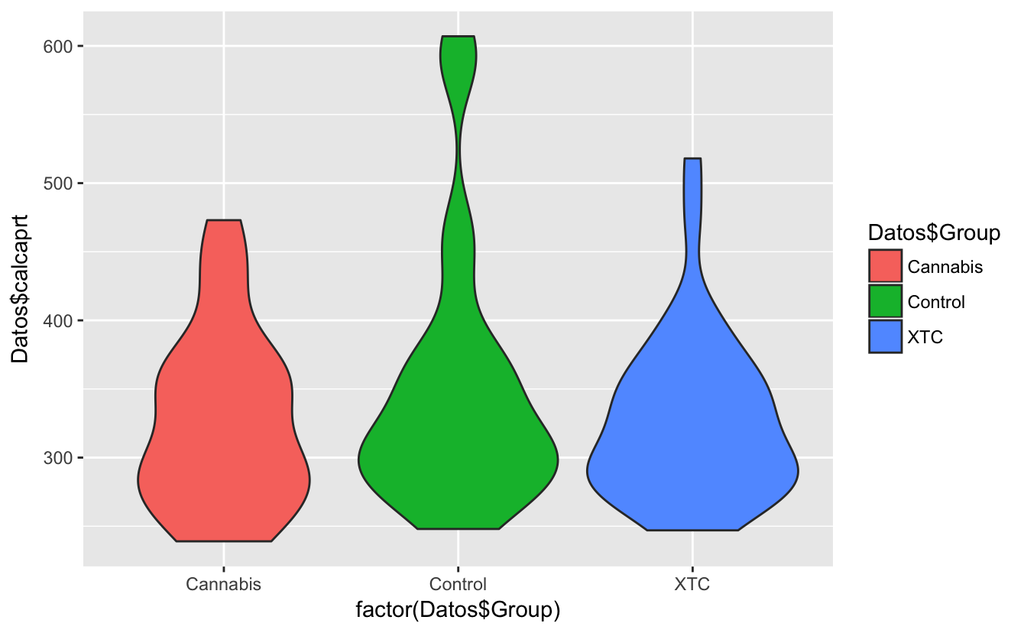

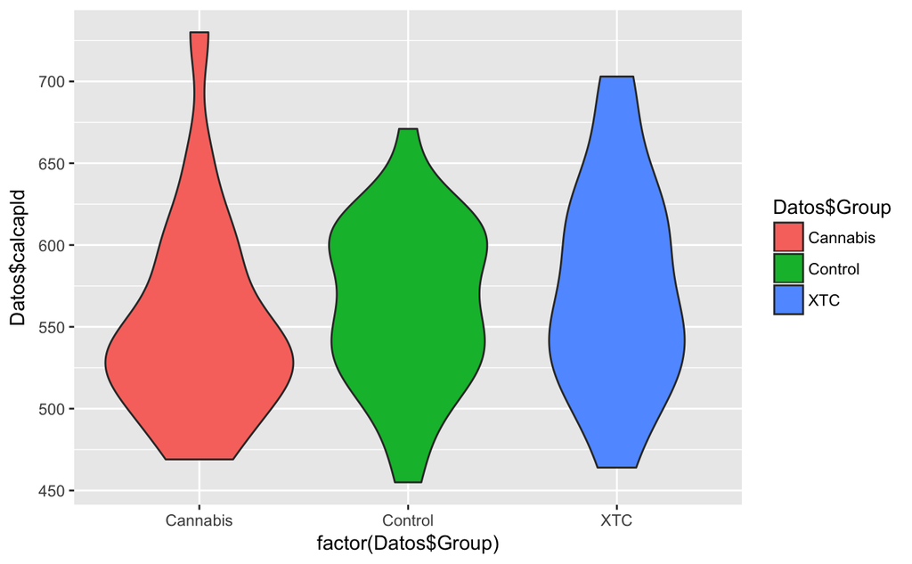

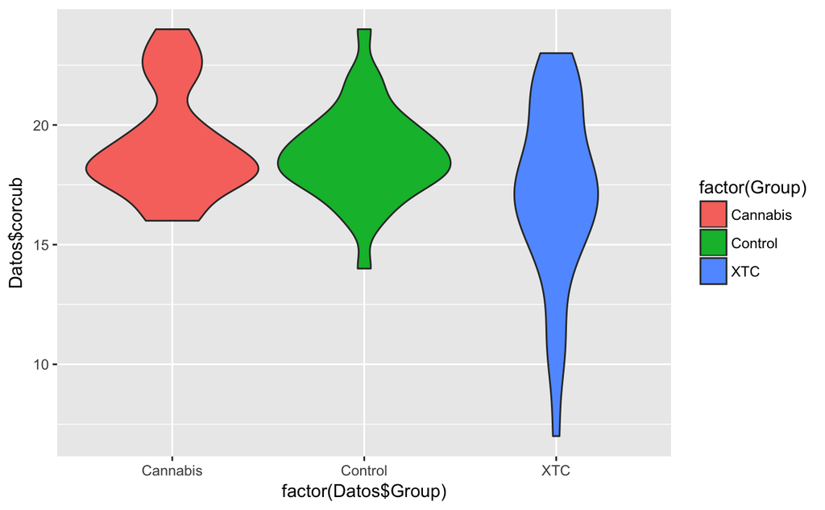

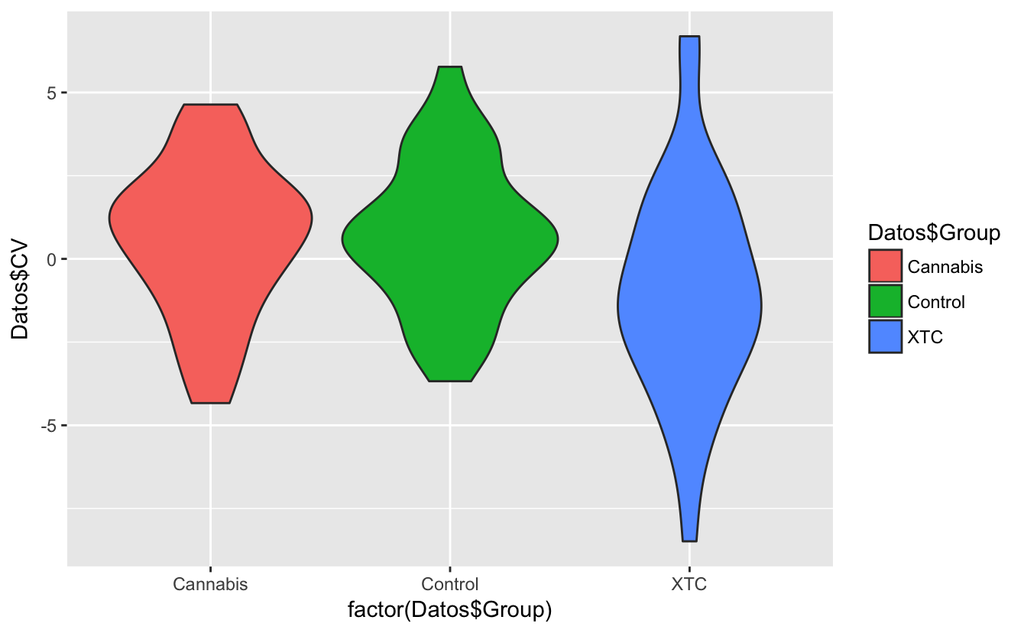

```r
# CV : composite variable
ggplot(Datos, aes(factor(Datos$Group), Datos$CV)) +
  geom_violin(aes(fill = Datos$Group))
```

- Segundo tipo de gráfico:

ESTE GRÁFICO ES INÚTIL A MÁS NO PODER

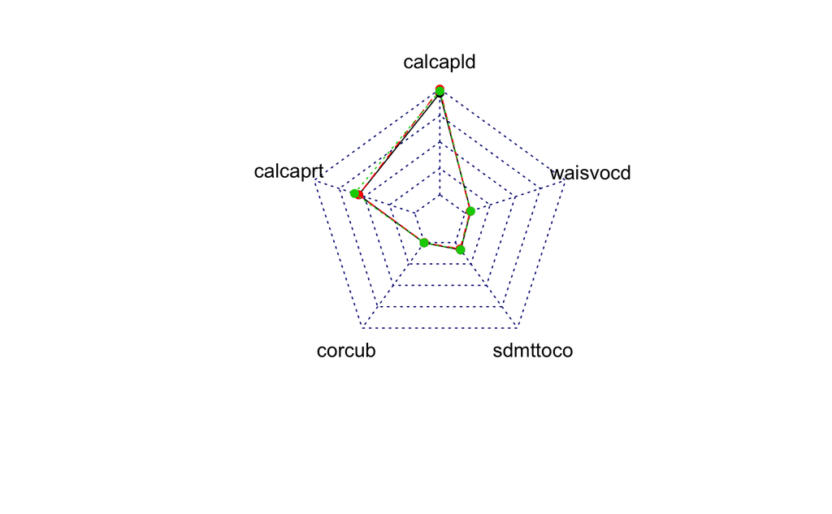